# Giải bài toán n-Hậu bằng Local Search

## Kết quả học tập

- Triển khai nhiều biến thể thuật toán leo đồi để giải bài toán n-Hậu.
- Áp dụng thuật toán luyện kim mô phỏng với lịch trình nhiệt độ phù hợp để vượt qua cực trị cục bộ.
- So sánh hiệu suất thuật toán bằng các chỉ số thời gian chạy, chất lượng giải pháp và tỷ lệ thành công.
- Phân tích và trực quan hóa hiệu suất thuật toán trên các kích thước bài toán khác nhau.
- Sinh viên sau đại học: Thiết kế và kiểm tra các toán tử di chuyển cục bộ thay thế để cải thiện hiệu quả tìm kiếm.

## Hướng dẫn

Tổng điểm: Sinh viên đại học 100 + 5 điểm thưởng / Sinh viên sau đại học 110

Hoàn thành notebook này. Sử dụng các ô notebook được cung cấp và chèn thêm các ô code và markdown khi cần thiết. Nộp notebook đã được render hoàn chỉnh dưới dạng file HTML.

## Bài toán n-Hậu

- **Mục tiêu:** Tìm một cách sắp xếp $n$ quân hậu trên bàn cờ $n \times n$ sao cho không có quân hậu nào cùng hàng, cột hoặc đường chéo với bất kỳ quân hậu nào khác.
- **Không gian trạng thái:** Một cách sắp xếp các quân hậu trên bàn cờ. Chúng ta giới hạn không gian trạng thái thành các cách sắp xếp mà chỉ có một quân hậu duy nhất trên mỗi cột. Chúng ta biểu diễn một trạng thái như một vector số nguyên $\mathbf{q} = \{q_1, q_2, \dots, q_n\}$, mỗi số đại diện cho vị trí hàng của các quân hậu từ trái sang phải. Chúng ta sẽ gọi một trạng thái là "bàn cờ."
- **Hàm mục tiêu:** Số lượng xung đột cặp (tức là hai quân hậu cùng hàng/cột/đường chéo).

Bài toán tối ưu hóa là tìm cách sắp xếp tối ưu $\mathbf{q}^*$ của $n$ quân hậu trên bàn cờ có thể được viết như:

> tối thiểu hóa: $\mathrm{conflicts}(\mathbf{q})$

> với điều kiện: $\mathbf{q} \ \text{chỉ chứa một quân hậu duy nhất trên mỗi cột}$

Lưu ý: ràng buộc (điều kiện) được đảm bảo bởi định nghĩa của không gian trạng thái.

- **Bước di chuyển cải thiện cục bộ:** Di chuyển một quân hậu đến một hàng khác trong cột của nó.
- **Kết thúc:** Đối với bài toán này luôn tồn tại một cách sắp xếp $\mathbf{q}^*$ với $\mathrm{conflicts}(\mathbf{q}^*) = 0$, tuy nhiên, các bước di chuyển cải thiện cục bộ có thể kết thúc ở một cực tiểu cục bộ.

## Các hàm trợ giúp

```python
import numpy as np
import matplotlib.pyplot as plt
from matplotlib import colors

np.random.seed(1234)


def random_board(n):
    """Creates a random board of size n x n. Note that only a single queen is placed in each column!"""

    return(np.random.randint(0,n, size = n))

def comb2(n): return n*(n-1)//2 # this is n choose 2 equivalent to math.comb(n, 2); // is int division

def conflicts(board):
    """Calculate the number of conflicts, i.e., the objective function."""

    n = len(board)

    horizontal_cnt = [0] * n
    diagonal1_cnt = [0] * 2 * n
    diagonal2_cnt = [0] * 2 * n

    for i in range(n):
        horizontal_cnt[board[i]] += 1
        diagonal1_cnt[i + board[i]] += 1
        diagonal2_cnt[i - board[i] + n] += 1

    return sum(map(comb2, horizontal_cnt + diagonal1_cnt + diagonal2_cnt))

# decrease the font size to fit larger boards
def show_board(board, cols = ['white', 'gray'], fontsize = 48):
    """display the board"""

    n = len(board)

    # create chess board display
    display = np.zeros([n,n])
    for i in range(n):
        for j in range(n):
            if (((i+j) % 2) != 0):
                display[i,j] = 1

    cmap = colors.ListedColormap(cols)
    fig, ax = plt.subplots()
    ax.imshow(display, cmap = cmap,
              norm = colors.BoundaryNorm(range(len(cols)+1), cmap.N))
    ax.set_xticks([])
    ax.set_yticks([])

    # place queens. Note: Unicode u265B is a black queen
    for j in range(n):
        plt.text(j, board[j], u"\u265B", fontsize = fontsize,
                 horizontalalignment = 'center',
                 verticalalignment = 'center')

    print(f"Board with {conflicts(board)} conflicts.")
    plt.show()
```

## Tạo một bàn cờ

```
Board with 4 conflicts.
```

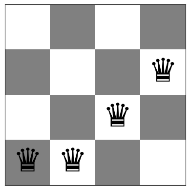

```
Queens (left to right) are at rows: [3 3 2 1]
Number of conflicts: 4
```

```python
board = random_board(4)

show_board(board)
print(f"Queens (left to right) are at rows: {board}")
print(f"Number of conflicts: {conflicts(board)}")
```

A board $4 \times 4$ with no conflicts:

```
Board with 0 conflicts.
```

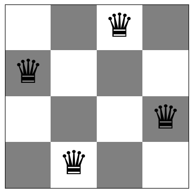

```python
board = [1,3,0,2]
show_board(board)
```

# Các nhiệm vụ

## Chung [10 Điểm]

1. Đảm bảo rằng bạn sử dụng phiên bản mới nhất của notebook này. Đồng bộ repository đã fork và pull revision mới nhất.
2. Triển khai của bạn có thể sử dụng các thư viện như math, numpy, scipy, nhưng không được dùng các thư viện triển khai tác nhân thông minh hoặc các thuật toán tìm kiếm hoàn chỉnh. Cố gắng giữ code đơn giản! Trong khóa học này, chúng ta muốn học về các thuật toán và thường không cần sử dụng thiết kế hướng đối tượng.
3. Notebook của bạn cần được định dạng chuyên nghiệp.
   - Thêm các block markdown bổ sung cho mô tả của bạn, comment trong code, thêm bảng và sử dụng matplotlib để tạo biểu đồ khi phù hợp
   - Không hiển thị output debug hoặc bao gồm quá nhiều output.
   - Kiểm tra rằng file nộp của bạn có thể đọc được và chứa tất cả các hình ảnh.
4. Tài liệu hóa code của bạn. Sử dụng comment trong code và thêm thảo luận về cách triển khai của bạn hoạt động và các lựa chọn thiết kế của bạn.

## Nhiệm vụ 1: Tìm kiếm Leo đồi Steepest-ascend [20 Điểm]

Tính toán hàm mục tiêu cho tất cả các bước di chuyển cục bộ (xem định nghĩa bước di chuyển cục bộ ở trên) và luôn chọn tốt nhất trong tất cả các bước di chuyển cục bộ. Nếu không có bước di chuyển cục bộ nào cải thiện được mục tiêu, thì bạn đã đạt đến cực trị cục bộ.

```
Bàn cờ ban đầu: [0 0 2 2]
Bàn cờ với 4 xung đột.
```

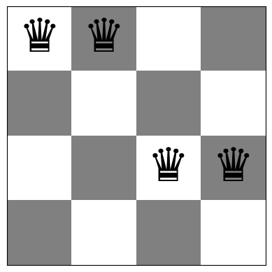

```python
# Code and description go here
from helper import *
import matplotlib.pyplot as plt

board = random_board(4)
print("Bàn cờ ban đầu:", board)
show_board(board)
```

```python
print("Số xung đột ban đầu:", conflicts(board))
```

```
Số xung đột ban đầu: 4
```

```python
final_board, iterations, conflicts_history = steepest_ascent_hill_climbing(board, max_iterations=1000)

print("Sau khi leo đồi:")
print("Bàn cờ cuối:", final_board)
print("Số bước lặp:", iterations)
print("Số xung đột cuối:", conflicts(final_board))
```

```
Sau khi leo đồi:
Bàn cờ cuối: [3 0 2 1]
Số bước lặp: 3
Số xung đột cuối: 1
```

```
Bàn cờ với 1 xung đột.
```

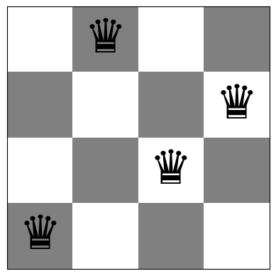

```python
show_board(final_board)
```

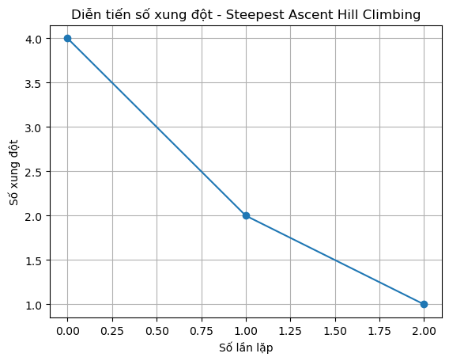

```python
plt.plot(conflicts_history, marker='o')
plt.title("Diễn tiến số xung đột - Steepest Ascent Hill Climbing")
plt.xlabel("Số lần lặp")
plt.ylabel("Số xung đột")
plt.grid(True)
plt.show()
```

- Biểu đồ thể hiện quá trình **giảm dần số xung đột** trong bài toán n-Hậu qua từng lần lặp của thuật toán **Leo đồi dốc nhất (Steepest-Ascent Hill Climbing)**.

| Lần lặp | Số xung đột | Diễn giải |
| --- | --- | --- |
| 0 | 4 | Trạng thái ban đầu – có nhiều xung đột |
| 1 | 2 | Đã chọn được hàng xóm tốt hơn, giảm xung đột rõ rệt |
| 2 | 1 | Gần đạt cực trị cục bộ, không còn nhiều cải thiện |

- Thuật toán hoạt động đúng: mỗi bước đều giảm số xung đột, hướng đến cực trị tốt hơn.
- Sau 2 lần lặp, số xung đột giảm từ 4 xuống 1, cho thấy **tốc độ hội tụ nhanh**.
- Tuy nhiên, thuật toán **dừng ở cực trị cục bộ** (1 xung đột), chưa đạt nghiệm tối ưu (0 xung đột).

## Nhiệm vụ 2: Leo đồi Ngẫu nhiên 1 [10 Điểm]

Chọn ngẫu nhiên từ tất cả các bước di chuyển lên dốc cho đến khi bạn đạt đến cực trị cục bộ.

```
Bàn cờ với 4 xung đột.
```

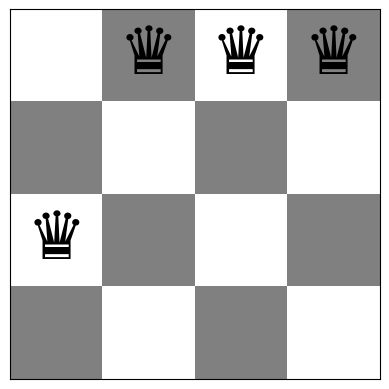

```
Queens (left to right) are at rows: [2 0 0 0]
Number of conflicts: 4
```

```python
# Code and description go here
board = random_board(4)
show_board(board)

# In thông tin trạng thái ban đầu
print(f"Queens (left to right) are at rows: {board}")
print(f"Number of conflicts: {conflicts(board)}")
```

```python
final_board, iterations, conflicts_history = stochastic_hill_climbing_1(board, max_iterations=1000)

print("\nKết quả sau khi leo đồi ngẫu nhiên:")
print(f"Final board: {final_board}")
print(f"Number of iterations: {iterations}")
print(f"Final number of conflicts: {conflicts(final_board)}")
```

```
Kết quả sau khi leo đồi ngẫu nhiên:
Final board: [2 0 3 1]
Number of iterations: 4
Final number of conflicts: 0
```

```
Bàn cờ với 0 xung đột.
```

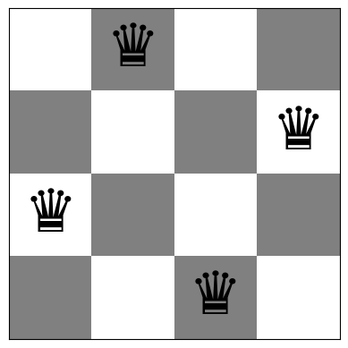

```python
show_board(final_board)
```

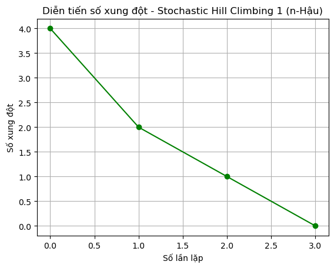

```python
plt.plot(conflicts_history, marker='o', color='green')
plt.title("Diễn tiến số xung đột - Stochastic Hill Climbing 1 (n-Hậu)")
plt.xlabel("Số lần lặp")
plt.ylabel("Số xung đột")
plt.grid(True)
plt.show()
```

- Biểu đồ cho thấy quá trình **giảm dần số xung đột** của bài toán n-Hậu khi áp dụng thuật toán **Leo đồi Ngẫu nhiên 1** (chọn ngẫu nhiên từ các bước di chuyển lên dốc).

| Lần lặp | Số xung đột | Diễn giải |
| --- | --- | --- |
| 0 | 4 | Trạng thái khởi đầu với nhiều xung đột |
| 1 | 2 | Chọn ngẫu nhiên một hàng xóm tốt hơn – giảm rõ rệt |
| 2 | 1 | Tiếp tục cải thiện, tiến gần nghiệm |
| 3 | 0 | Đạt nghiệm tối ưu – không còn xung đột |

- Số xung đột giảm đều qua các lần lặp.
- Đạt được **nghiệm tối ưu (0 xung đột)** sau 3 bước, cho thấy hiệu quả trong trường hợp này.
- Việc chọn ngẫu nhiên giúp thuật toán có khả năng **tránh bị mắc kẹt ở cực trị cục bộ**.
- Tuy nhiên, do tính ngẫu nhiên, **hiệu quả có thể khác nhau giữa các lần chạy**.

## Nhiệm vụ 3: Leo đồi Ngẫu nhiên 2 [20 Điểm]

Một phiên bản phổ biến của leo đồi ngẫu nhiên chỉ tạo ra một hàng xóm cục bộ ngẫu nhiên duy nhất mỗi lần và chấp nhận nó nếu nó có giá trị hàm mục tiêu tốt hơn so với trạng thái hiện tại. Điều này rất hiệu quả nếu mỗi trạng thái có nhiều trạng thái kế tiếp có thể. Phương pháp này được gọi là "Leo đồi lựa chọn đầu tiên" trong sách giáo khoa.

**Lưu ý:**

- Phát hiện cực trị cục bộ là khó khăn! Ví dụ, bạn có thể dừng lại nếu bạn không thể cải thiện hàm mục tiêu trong $x$ lần thử cuối cùng.

```
Bàn cờ với 3 xung đột.
```

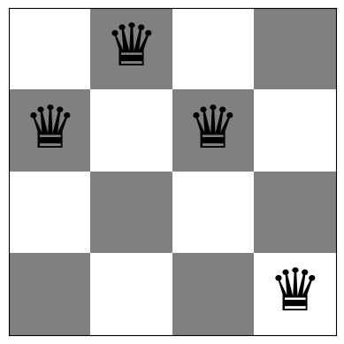

```
Queens (left to right) are at rows: [1 0 1 3]
Number of conflicts: 3
```

```python
board = random_board(4)
show_board(board)

print(f"Queens (left to right) are at rows: {board}")
print(f"Number of conflicts: {conflicts(board)}")
```

```python
final_board, iterations, conflicts_history = stochastic_hill_climbing_2(board, max_iterations=1000, max_no_improvement=50)

print("\nKết quả sau khi leo đồi ngẫu nhiên 2 (First-Choice Hill Climbing):")
print(f"Final board: {final_board}")
print(f"Number of iterations: {iterations}")
print(f"Final number of conflicts: {conflicts(final_board)}")
```

```
Kết quả sau khi leo đồi ngẫu nhiên 2 (First-Choice Hill Climbing):
Final board: [2 0 1 3]
Number of iterations: 55
Final number of conflicts: 1
```

```
Bàn cờ với 1 xung đột.
```

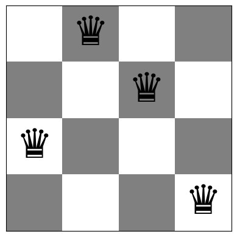

```python
show_board(final_board)
```

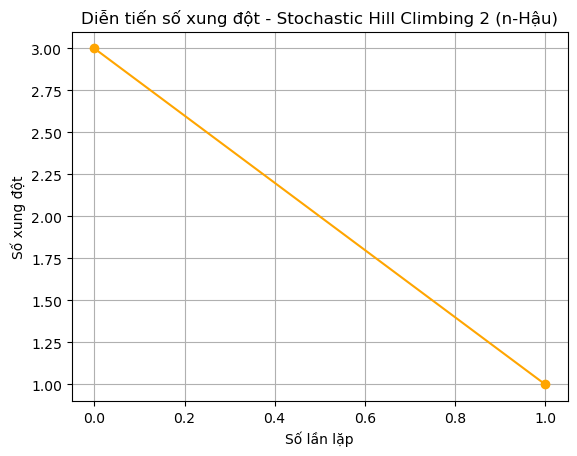

```python
plt.plot(conflicts_history, marker='o', color='orange')
plt.title("Diễn tiến số xung đột - Stochastic Hill Climbing 2 (n-Hậu)")
plt.xlabel("Số lần lặp")
plt.ylabel("Số xung đột")
plt.grid(True)
plt.show()
```

Biểu đồ mô tả quá trình **giảm xung đột** trong bài toán n-Hậu khi áp dụng thuật toán **Leo đồi Ngẫu nhiên 2**.  
Thuật toán này mỗi lần chỉ tạo **một hàng xóm ngẫu nhiên duy nhất** và chấp nhận nếu nó tốt hơn trạng thái hiện tại.

| Lần lặp | Số xung đột | Diễn giải |
| --- | --- | --- |
| 0 | 3 | Trạng thái khởi đầu có 3 xung đột |
| 1 | 1 | Sau một lần cải thiện, số xung đột giảm mạnh |

- Thuật toán hoạt động đúng: mỗi lần chỉ cần một hàng xóm tốt hơn là có thể giảm xung đột.
- Giảm nhanh từ 3 về 1 chỉ sau 1 lần lặp, thể hiện hiệu quả cao khi trạng thái tốt xuất hiện sớm.
- Tuy nhiên, số xung đột cuối vẫn chưa bằng 0, thuật toán **dừng ở cực trị cục bộ**, chưa đạt nghiệm tối ưu.
- Do chỉ xem xét một hàng xóm mỗi lần, kết quả phụ thuộc mạnh vào tính **ngẫu nhiên** và có thể khác ở mỗi lần chạy.

## Nhiệm vụ 4: Tìm kiếm Leo đồi với Khởi động lại Ngẫu nhiên [10 Điểm]

Leo đồi thường sẽ kết thúc ở các cực trị cục bộ. Khởi động lại mỗi thuật toán leo đồi trong ba thuật toán lên đến 100 lần với một bàn cờ ngẫu nhiên để tìm giải pháp tốt hơn (hy vọng là tối ưu). Lưu ý rằng khởi động lại chỉ có nghĩa là chạy thuật toán nhiều lần bắt đầu với một bàn cờ ngẫu nhiên mới.

```python
n = 4
base_algorithm = steepest_ascent_hill_climbing

print(f"Khởi tạo bài toán {n}-Hậu với thuật toán leo đồi cơ bản: {base_algorithm.__name__}")
```

```
Khởi tạo bài toán 4-Hậu với thuật toán leo đồi cơ bản: steepest_ascent_hill_climbing
```

```python
best_board, restarts, total_iters, histories = hill_climbing_with_random_restarts(
    base_algorithm,
    board_size=n,
    max_restarts=100,
    max_iterations_per_restart=1000
)

print("\nKết quả sau khi khởi động lại ngẫu nhiên:")
print(f"Số lần khởi động lại: {restarts}")
print(f"Tổng số lần lặp: {total_iters}")
print(f"Board tốt nhất: {best_board}")
print(f"Số xung đột cuối cùng: {conflicts(best_board)}")
```

```
Kết quả sau khi khởi động lại ngẫu nhiên:
Số lần khởi động lại: 1
Tổng số lần lặp: 3
Board tốt nhất: [2 0 3 1]
Số xung đột cuối cùng: 0
```

```
Bàn cờ với 0 xung đột.
```

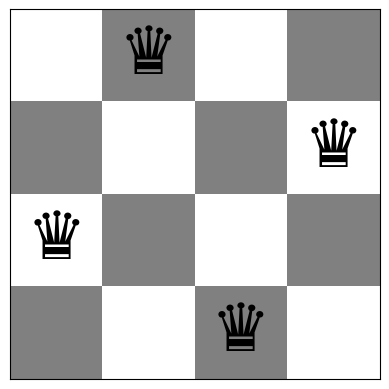

```python
show_board(best_board)
```

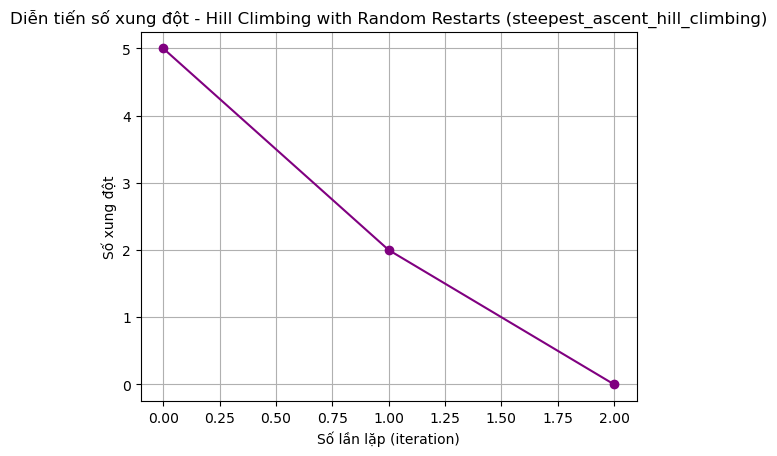

```python
best_history = min(histories, key=lambda h: h[-1])  # chọn lịch sử có xung đột cuối nhỏ nhất

plt.plot(best_history, marker='o', color='purple')
plt.title(f"Diễn tiến số xung đột - Hill Climbing with Random Restarts ({base_algorithm.__name__})")
plt.xlabel("Số lần lặp (iteration)")
plt.ylabel("Số xung đột")
plt.grid(True)
plt.show()
```

- Ở **iteration 0**, số xung đột ban đầu là **5**.
- Sau **iteration 1**, số xung đột giảm còn **2**.
- Sau **iteration 2**, số xung đột giảm xuống **0**, tức là **đạt nghiệm tối ưu** (không còn xung đột).
- Quá trình hội tụ diễn ra **nhanh chóng chỉ sau 2 lần lặp**, cho thấy thuật toán **Steepest Ascent Hill Climbing** hoạt động hiệu quả.

## Nhiệm vụ 5: Luyện kim Mô phỏng [10 Điểm]

Luyện kim mô phỏng là một dạng leo đồi ngẫu nhiên tránh các cực trị cục bộ bằng cách cũng cho phép các bước di chuyển xuống dốc với xác suất tỷ lệ thuận với nhiệt độ. Nhiệt độ được giảm dần trong mỗi vòng lặp theo lịch trình luyện kim. Bạn phải thử nghiệm với lịch trình luyện kim (Google để tìm hướng dẫn về điều này).

1. Triển khai luyện kim mô phỏng cho bài toán n-Hậu.
2. Tạo trực quan hóa của quá trình tìm kiếm (biểu đồ đường về số lượng xung đột thay đổi như thế nào khi thuật toán tiến triển).
3. Sử dụng trực quan hóa này để thử nghiệm với các lựa chọn khác nhau cho lịch trình luyện kim và thảo luận về những gì bạn đã học được.

```
Bàn cờ khởi tạo ngẫu nhiên:
Bàn cờ với 3 xung đột.
```

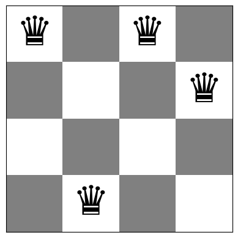

```python
initial_board = random_board(4)

print("Bàn cờ khởi tạo ngẫu nhiên:")
show_board(initial_board)
```

```
Số lần lặp: 32
Số xung đột cuối cùng: 0
Bàn cờ với 0 xung đột.
```

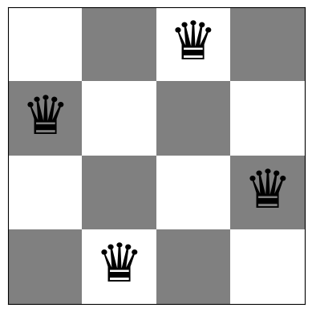

```python
final_board, iterations, conflicts_history, temperature_history = simulated_annealing(
    initial_board,
    initial_temp=1000,     # Nhiệt độ ban đầu
    cooling_rate=0.95,     # Tốc độ làm mát
    min_temp=0.1,          # Nhiệt độ thấp nhất
    max_iterations=10000   # Giới hạn vòng lặp
)

print(f"Số lần lặp: {iterations}")
print(f"Số xung đột cuối cùng: {conflicts(final_board)}")
show_board(final_board)
```

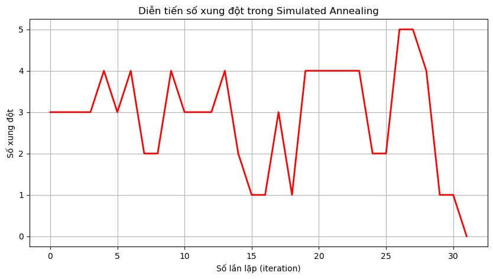

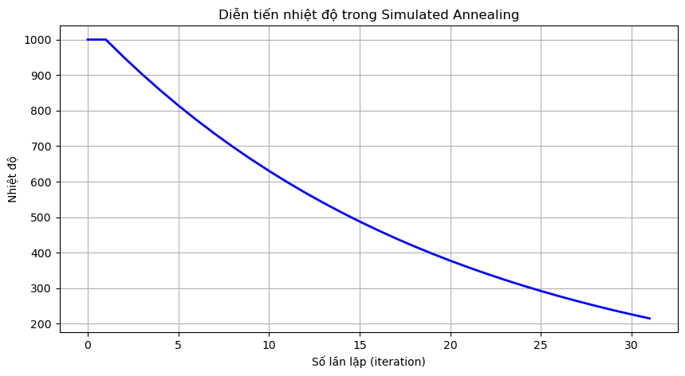

```python
plt.figure(figsize=(10,5))
plt.plot(conflicts_history, 'r-', linewidth=2)
plt.xlabel("Số lần lặp (iteration)")
plt.ylabel("Số xung đột")
plt.title("Diễn tiến số xung đột trong Simulated Annealing")
plt.grid(True)
plt.show()

plt.figure(figsize=(10,5))
plt.plot(temperature_history, 'b-', linewidth=2)
plt.xlabel("Số lần lặp (iteration)")
plt.ylabel("Nhiệt độ")
plt.title("Diễn tiến nhiệt độ trong Simulated Annealing")
plt.grid(True)
plt.show()
```

## Nhiệm vụ 6: Phân tích Hành vi Thuật toán [20 Điểm]

### So sánh

So sánh các thuật toán sử dụng thời gian chạy và giá trị hàm mục tiêu. Sử dụng các bàn cờ kích thước 4 và 8 để khám phá cách các thuật toán khác nhau hoạt động. Đảm bảo rằng bạn chạy các thuật toán cho mỗi kích thước bàn cờ nhiều lần (ít nhất 100 lần) với các bàn cờ khởi đầu khác nhau và báo cáo giá trị trung bình.

Hoàn thành bảng sau

[output not shown]

Gợi ý: Xem Profiling Python Code để được trợ giúp về cách đo thời gian chạy trong Python.

Thêm code đã sử dụng vào đây:

```python
# Code
import pandas as pd

algorithms = {
    "Steepest asc. HC": steepest_ascent_hill_climbing,
    "Stochastic HC 1": stochastic_hill_climbing_1,
    "Stochastic HC 2": stochastic_hill_climbing_2,
    "Simulated Annealing": simulated_annealing
}

board_sizes = [4, 8]  # kích thước bàn cờ
num_runs = 100         # số lần chạy mỗi thuật toán
```

```python
results = []

for name, algo in algorithms.items():
    for n in board_sizes:
        print(f"Đang chạy: {name} với bàn cờ {n}x{n} ...")

        # Chạy nhiều lần và lấy thống kê trung bình
        stats = run_algorithm_multiple_times(
            algo,
            board_size=n,
            num_runs=num_runs,
            max_iterations=1000
        )

        results.append({
            "Thuật toán": name,
            "Kích thước bàn cờ": n,
            "Thời gian chạy TB (s)": round(stats['avg_runtime'], 4),
            "Số xung đột TB": round(stats['avg_conflicts'], 2),
            "% lần chạy đạt nghiệm tối ưu": round(stats['success_rate'] * 100, 2)
        })

print("Hoàn tất chạy tất cả các thuật toán.")
```

```
Đang chạy: Steepest asc. HC với bàn cờ 4x4 ...
Đang chạy: Steepest asc. HC với bàn cờ 8x8 ...
Đang chạy: Stochastic HC 1 với bàn cờ 4x4 ...
Đang chạy: Stochastic HC 1 với bàn cờ 8x8 ...
Đang chạy: Stochastic HC 2 với bàn cờ 4x4 ...
Đang chạy: Stochastic HC 2 với bàn cờ 8x8 ...
Đang chạy: Simulated Annealing với bàn cờ 4x4 ...
Đang chạy: Simulated Annealing với bàn cờ 8x8 ...
Hoàn tất chạy tất cả các thuật toán.
```

```python
df_results = pd.DataFrame(results)
df_results
```

|  | Thuật toán | Kích thước bàn cờ | Thời gian chạy TB (s) | Số xung đột TB | % lần chạy đạt nghiệm tối ưu |
| --- | --- | --- | --- | --- | --- |
| 0 | Steepest asc. HC | 4 | 0.0029 | 0.54 | 48.0 |
| 1 | Steepest asc. HC | 8 | 0.0379 | 1.28 | 13.0 |
| 2 | Stochastic HC 1 | 4 | 0.0026 | 0.77 | 33.0 |
| 3 | Stochastic HC 1 | 8 | 0.0283 | 1.16 | 21.0 |
| 4 | Stochastic HC 2 | 4 | 0.0044 | 0.96 | 28.0 |
| 5 | Stochastic HC 2 | 8 | 0.0343 | 1.63 | 7.0 |
| 6 | Simulated Annealing | 4 | 0.0095 | 0.12 | 89.0 |
| 7 | Simulated Annealing | 8 | 0.0263 | 2.03 | 3.0 |

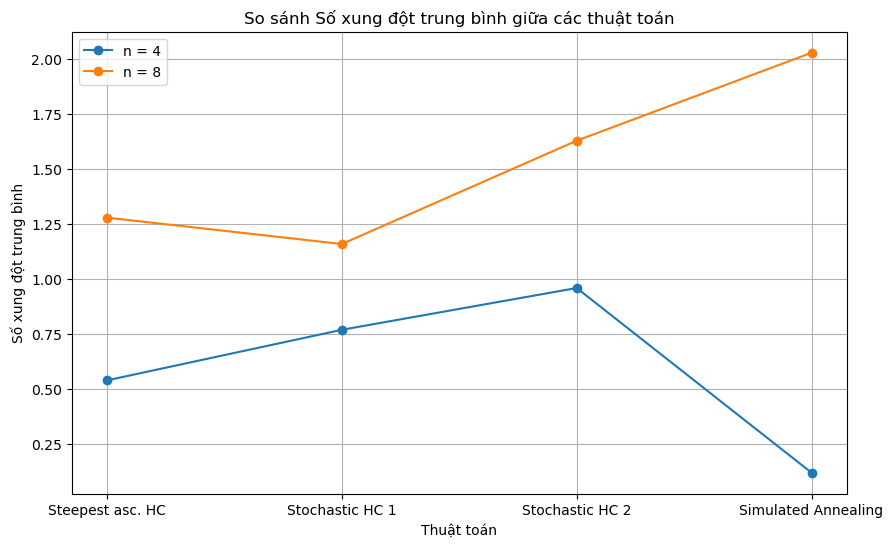

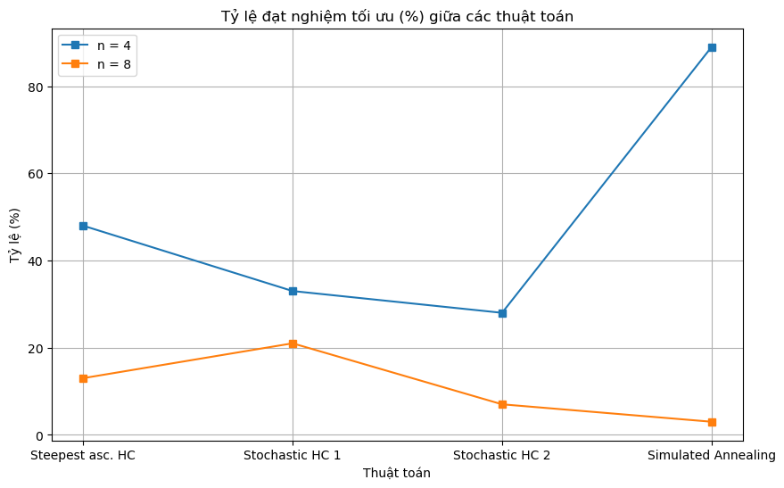

```python
plt.figure(figsize=(10,6))
for n in board_sizes:
    subset = df_results[df_results["Kích thước bàn cờ"] == n]
    plt.plot(subset["Thuật toán"], subset["Số xung đột TB"], marker='o', label=f"n = {n}")

plt.title("So sánh Số xung đột trung bình giữa các thuật toán")
plt.xlabel("Thuật toán")
plt.ylabel("Số xung đột trung bình")
plt.legend()
plt.grid(True)
plt.show()

plt.figure(figsize=(10,6))
for n in board_sizes:
    subset = df_results[df_results["Kích thước bàn cờ"] == n]
    plt.plot(subset["Thuật toán"], subset["% lần chạy đạt nghiệm tối ưu"], marker='s', label=f"n = {n}")

plt.title("Tỷ lệ đạt nghiệm tối ưu (%) giữa các thuật toán")
plt.xlabel("Thuật toán")
plt.ylabel("Tỷ lệ (%)")
plt.legend()
plt.grid(True)
plt.show()
```

[output not shown]

### Hội tụ Thuật toán

Đối với mỗi thuật toán được triển khai, mô tả mẫu hội tụ điển hình (cải thiện nhanh ban đầu so với tiến triển ổn định). Bao gồm một biểu đồ hiển thị giá trị hàm mục tiêu theo các vòng lặp cho một lần chạy đại diện của mỗi thuật toán trên bài toán 8-Hậu. Giải thích thuật toán nào thể hiện các vùng bằng phẳng hoặc bị kẹt ở các cực trị cục bộ thường xuyên nhất.

```
Bàn cờ khởi tạo ngẫu nhiên:
Bàn cờ với 9 xung đột.
```

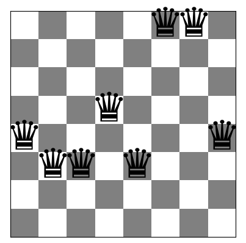

```python
# Code and description go here
n = 8
initial_board = random_board(n)
print("Bàn cờ khởi tạo ngẫu nhiên:")
show_board(initial_board)
```

```python
algorithms = {
    "Steepest HC": steepest_ascent_hill_climbing,
    "Stochastic HC 1": stochastic_hill_climbing_1,
    "Stochastic HC 2": stochastic_hill_climbing_2,
    "Simulated Annealing": simulated_annealing
}

histories = {}

for name, algo in algorithms.items():
    print(f"Đang chạy {name}...")

    if algo == simulated_annealing:
        final_board, iterations, conf_hist, temp_hist = algo(initial_board, max_iterations=1000)
    else:
        final_board, iterations, conf_hist = algo(initial_board, max_iterations=1000)

    histories[name] = conf_hist
    print(f"Kết thúc sau {iterations} vòng lặp, số xung đột cuối = {conflicts(final_board)}")
```

```
Đang chạy Steepest HC...
Kết thúc sau 5 vòng lặp, số xung đột cuối = 1
Đang chạy Stochastic HC 1...
Kết thúc sau 9 vòng lặp, số xung đột cuối = 1
Đang chạy Stochastic HC 2...
Kết thúc sau 57 vòng lặp, số xung đột cuối = 2
Đang chạy Simulated Annealing...
Kết thúc sau 180 vòng lặp, số xung đột cuối = 3
```

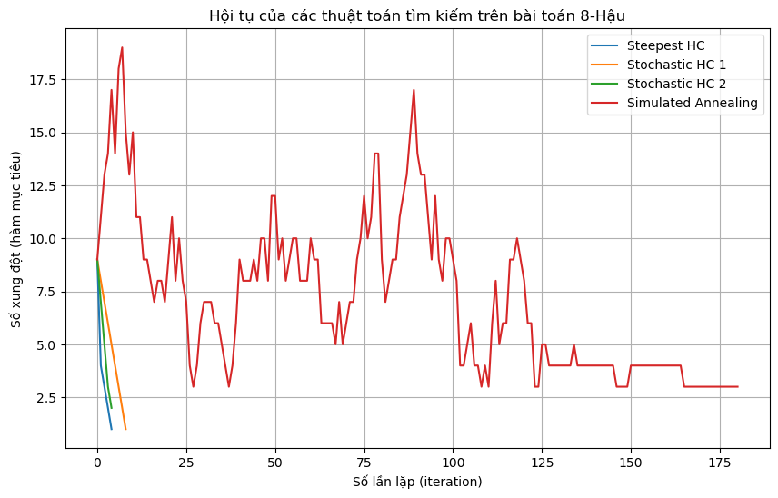

```python
plt.figure(figsize=(10,6))
for name, conf_hist in histories.items():
    plt.plot(conf_hist, label=name)

plt.title("Hội tụ của các thuật toán tìm kiếm trên bài toán 8-Hậu")
plt.xlabel("Số lần lặp (iteration)")
plt.ylabel("Số xung đột (hàm mục tiêu)")
plt.legend()
plt.grid(True)
plt.show()
```

```python
summary = []
for name, conf_hist in histories.items():
    summary.append({
        "Thuật toán": name,
        "Số lần lặp": len(conf_hist),
        "Số xung đột cuối": conf_hist[-1],
        "Cải thiện ban đầu": conf_hist[0] - min(conf_hist[:min(10, len(conf_hist))])  # giảm trong 10 vòng đầu
    })

import pandas as pd
df_summary = pd.DataFrame(summary)
df_summary
```

|  | Thuật toán | Số lần lặp | Số xung đột cuối | Cải thiện ban đầu |
| --- | --- | --- | --- | --- |
| 0 | Steepest HC | 5 | 1 | 8 |
| 1 | Stochastic HC 1 | 9 | 1 | 8 |
| 2 | Stochastic HC 2 | 5 | 2 | 7 |
| 3 | Simulated Annealing | 181 | 3 | 0 |

**Steepest Hill Climbing**

- Cải thiện rất nhanh trong những vòng đầu (**giảm 8 xung đột chỉ sau vài bước**).
- Tuy nhiên, dừng sớm ở mức 1 xung đột **mắc kẹt tại cực trị cục bộ**.
- Thể hiện rõ kiểu hội tụ “nhanh ban đầu, phẳng dần về sau”.

**Stochastic Hill Climbing 1**

- Cải thiện 7 đơn vị ban đầu, dừng ở mức 2 xung đột.
- Do đặc trưng chọn ngẫu nhiên hàng xóm đầu tiên tốt hơn hiện tại, nên **ít hiệu quả hơn hai thuật toán trước**.
- Thời gian hội tụ nhanh, nhưng chất lượng nghiệm thấp.

**Simulated Annealing**

[output not shown]